# Computational Statistics 12.1: Unsupervised learning

## Unsupervised learning

### Overview

This lesson introduces the concepts of factor analysis and clustering.

### Objectives

After completing this module, students should be able to:

1. Distinguish between supervised and unsupervised learning, and factor and cluster analysis.

### Readings

NA

## Introduction

**Previously:**

- The type of data used was limited to a few categorical or numerical variables.
- We wished to know whether a set of means were different (**t or F test**), or whether two categorical variables were independent (**Chi-Squared test**), or how to model some dependent variable $y$ as a linear or nonlinear function of a small number of independent variables $x_{1}$, $x_{2}$, …, $x_{k}$ etc. (**Multiple Regression**).
- Also, we payed special attention to the conditions necessary for correctly testing hypothesis and differentiate between causal effects and simple statistical association.

Now we are going to emphasize the role of statistical models in prediction.

**For the rest of the semester:**

We are going to use **machine learning** to improve the predictive power of our models.

### What is *machine learning*?

We are going to use the term **machine learning** to the use of algorithms and/or statistical models to make predictions or detect patterns in a dataset without explicitly choosing *a priori* what variables to use. In general, machine learning refers to the ability of computers to learn how to do something without a detailed set of instructions, and its applications go beyond their use in statistics, making the set of techniques called *machine learning* not always clear. Thus, when someone use the term machine learning is a good idea to first know what is their area of expertise to make an assumption to what set of techniques they are refering to.

From now on, instead of worrying about what variables to use due to concerns of potential omitted variable bias (OVB) or inaccuracy caused by multicollinearity we are going to let the *computer* decides what variables to use in order to explain the relationship among variables in the dataset. Machine learning does not promise to uncover causal relations, it is simply interested in explaining the overall variation of the dataset as a whole. As a result, machine learning is not a direct tool for hypothesis testing, but a method to summarize information by detecting how variables are related with each other.

Then, there is very little value in using machine learning when the number of variables in a dataset is small. That’s why machine learning has not replaced the traditional research methods based on multivariate analysis. But, in the presence of **big data**, data with a very large number of variables, machine learning allow us to reduce the number of variables that are relevant by detecting how they are related with each other, instead of us to manually selecting variables one by one.

### What is *big data*?

**Big data** refers to datasets with a very large amount of information. Either by having a large number of variables, a large number of observations, or, both. As you’ll see this distinction is important.

There are different types of *big data*

- Data with large number of observations (large $n$).
- Data with a large number of variables (large $k$).
- Data with both a large number of observations and large number of variables.

Salganik (2018): “The amount of information in the world is rapidly increasing, and more of that information is stored digitally, which facilitates analysis, transmission, and merging. All of this digital information has come to be called”big data" (Salganik, 2018: p. 3). As a result, is not rare to have datasets where the number of variables is $k > 100$ and the number of observations $n > 1,000,000$.

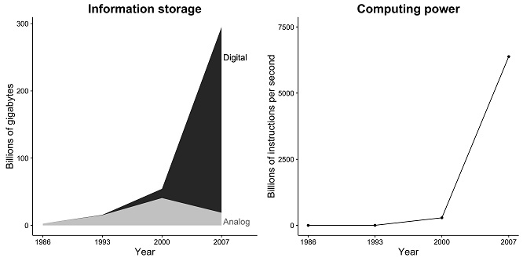

Adapted from Hilbert and Lopez (2011), figures 2 and 5.

### Large number of observations

When the dataset has a very large number of observations (large $n$) we often call it **long data**. Long data in general does not represent an issue in terms of modelling. This type of data is only as challenging as the power of the computer system:

This means that confidence intervals are going to be very small, and rejecting the hypothesis that a parameter is zero is very easy (almost trivial).

- In other words, a parameter may be statistically different than zero, because the confidence intervals are very small. That does not mean that the actual value of the parameter is *important*, for instance, if we estimate that the effect of distance on years of completed education is statistically significative, but the estimated parameter is $-0.000000000000000001$; then, even if the parameter is statistically significant, the variable is not *important* in practical terms, because the effect on years of education is negligible.

### Large number of variables

When the dataset has a very large number of variables (large $k$) then the modelling process described in the previous parts of the semester is not appropriate. Consider this:

- If $k$ is unusually large, it is possible that $n < k$. If this is the case we can’t run a regression, the reason for this is that we can perfectly fit the dependent variable $y$ with so many $x$ variables. Also, for some statistics like the F-test we’ll have meaningless negative degrees of freedom ($n-k-1 < 0$).
- When running a regression, the model fit will be **entirely arbitrary**, and will have no predictive power outside of the given $n$-item sample.
- Also, the traditional process of computing a correlation matrix and to check if the correlation with $y$ and $x$ is *large* to identify relevant omitted variables becomes impractical. Imagine having to inspect a correlation matrix with $k > 1,000$.
- Moreover, multicollinearity is almost guaranteed to be present. Recall that, as you add more variables to a model, the estimated parameters becomes more imprecise.

Then, in the presence of a large number of variables, we’ll probably have to use some method of machine learning to reduce the number of $k$ into something more manageable.

## Dealing with large $k$

- We are going to extend modeling method in regression models to include large numbers of independent variables. Can we aggregate the large number of potential independent variables ($x$’s) into a smaller number? For instance, start with $k = 100$ and then use machine learning to create three different artificial variables that summarize the variation in the original dataset, and use the newly reduced number of variables in the previous models. The problem is that the estimated parameters will be meaningless and not represent any causal effect. But, at least we can use the regression to make predictions.
- To implement this methodology, we need to find clusters or latent traits representing all or most of the variables in the dataset.

** Example:** Imagine that we are working for a retail store company, and we are hired to model consumer’s preference for the stores. Assume that the data comes from a survey of customers about their shopping experience in the different stores of the company. In this types of surveys, each observation is the answer of a single customer to a very large battery of questions. And generally, in long surveys, the questions are categorized by different topics and there may be 15 to 20 variables per topic. For instance, there may be a section asking about the brand loyalty of the customer, e.g. *“how often to you buy products of brand $x$?”*, *“is this the first time you buy at this store?”*, *“how often do you buy alternatives to product $x$?”* etc. Or, they may ask questions regarding the shopping experience at the store, e.g. *“did you have a hard time finding the product you were looking for?”*, *“were you greeted and/or thanked by one or more associates during your visit?”*, *“is the store apperance visually appealling?”*, etc. And the list goes on and on.

If we try to model this type of data with our traditional methods, it would be impossible to do a good job as the variables related to the same topic are likely to cause multicollinearity. Also, it would take a long time to decides what variables to include to reduce potential OVB. The traditional multivariate regression method is possible, but very hard and inefficient due to the high number of potential relevant variables.

Machine learning can be used to take the set of questions from each topic and create artificial variables that reflect the underlying concept of each group of variables. The power of machine learning is that we don’t have to specify what is the underlying concept behind the artificial variables, the computer will do that for us, the role of the researcher now is to simply interpret how good of a job are the resulting artificial variables.

## Types machine learning

In the next module we will tackle these issues by using the methods of **unsupervised machine learning**:

- **“Unsupervised learning”**: Take a large set of variables and observations, and try to detect a smaller set of underlying groups or factors beneath them.

Learning Module 12, that discuss **suppervised machine learning** will also be available for you, but it will not be part of the final exam and you’ll not have to submit a solution to the HW posted due to time constraints. But feel free to ask me questions in the discussion board or via email after the end of the semester.

- **“Supervised learning”**: Data is labeled, seeking to predict an *a priori* outcome or categorization.

## Factors and clusters

The two most common methodologies for conducting **unsupervised machine learning** (UML) are **factor analysis** and **cluster analysis**:

**Factor analysis:** looks for a smaller set of underlying dimensions, reduce the number of variables to a few latent variables.

**Cluster analysis:** looks for clusters of observations based on similarities on variables within clusters and dissimilarities of variables between clusters.

Both methods create artificial variables in the form of factors and clusters. They don’t require any *a priori* classification and are used to reduce the dimensionality of a dataset, thus, this methods will help us when dealing with large $k$.

### Factors vs clusters?

Both approaches may result in similar insights. For instance, consider the following simulated data.

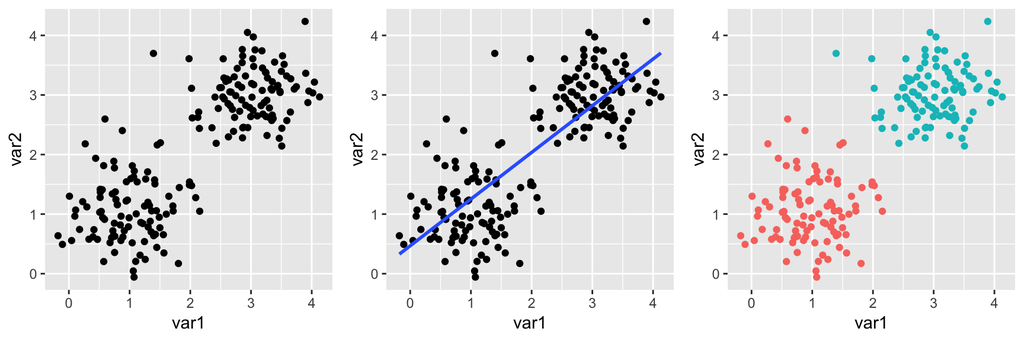

- On the left we see a plot of two variables against each other (e.g. hours spent on homework on the $x$ axis and course grade on the $y$, or years of education and earnings). By simple inspection we can detect two distinct clouds of data. One where observations share the commonality of having on average relatively low values of $x$ and $y$ and another group where the average values of $x$ and $y$ are relatively high. The goal of machine learning in this example is to summarize the information contained by variables $x$ and $y$ in a single variable. That is, reduce the dimension of the dataset from $k = 2$ to $k=1$.

**Using Factor Analysis:**

- These underlying factors can be modeled as **a single latent dimension**, which is represented by how far out on the blue line in the previous graph any observation is, and the position along this line is the measurements that capture an underlying latent variable. That is, values that are “high” on the blue line represent observations that have simultaneous high values of $x$ and $y$, and, values that are “low” on the blue line represent observations that have simultaneous low values of $x$ and $y$.
- Then, with a single **factor** we are able to represent the underlying dimension that accounts for most of the variation we see.

**Using Cluster Analysis:**

- Instead of representing the underlying dimension with a line, we can instead create discrete groups or clusters. The graph on the right shows how we can represent the two two variables by using a simple cluster categorization.

After we reduce the dimensionality of the data, now is the job of the researcher to interpret the meaning of the underlying dimension. This is the hardest part of using machine learning as it is subjective and generally requires some *a priori* expertise in the subject and data under consideration. For instance, if $x$ is hours spent on homework and $y$ is the course grade, then the underlying dimension may be interpret as work ethic, interest in the material, natural talent, productivity, or maybe even membership in a study group. We really don’t know, and unsupervised machine learning cannot objectively answer that question. This is not a minor problem, because, as you can see in the previous example, using the same method and results at least 5 different potential hypothesis can be plausible explanations for the same observed pattern.

In this simple example we reduced the dimensionality of the data from $k=2$ to $k=1$, not a big deal. The goal here was simply to give you a glimpse of how machine learning *looks like*, later on we’ll go over more powerful examples.